# Employer and Consumer NPS Forecast

## R Markdown

Summary:

This summary attempts a time-series analysis of of historic Member and Employer Net Promoter Scores.

Caveats:

1. Both provided data sets suffer from a paucity of data. More data points would provide a more accurate forecast. Unfortunately, the nature and period of performance of the surveys preclude having data as far back and as frequently as would be best for this type of analysis. With so few data points, some validation methods (‘Hold Out’, Time-Series Cross Validation, etc.) have poor indicative power, as they have an outsize effect on the test subset used.
2. To that end, performing forecasts on sentiment, as is the case with surveys, is notoriously unreliable. As such, the forecasts maintain two assumptions:
1. No changes to external variables that affect NPS.
2. No changes to methodology over the course of the data.

Method:

This summary uses an Auto-Regressive Integrated Moving Average(ARIMA) Regression. ARIMA regressions are a close cousin of standard Ordinary Least Squares Regressions that take into account the past behavior of variables to predict future periods. The standard ARIMA equation is as follows:

Y[t] = Y[t-1] + …Y[t-k] + e[t]

Where Y[t] is the variable in question at time ‘t’ (i.e. right now). Y[t-1] or Y[t-k] are past records of the variable. e[t] is the error, or the unknowable noise that feeds into the equation.

In order to perform the ARIMA on the data we are using the R statistical programming language. The following is a step through of the codes and method used for this analysis.

Step-through:

We then load the data sets provided. We have also formatted the data sets into data.tables for speed and coerced the two variables in each data set into ts() objects. R’s stats, tseries, and forecast packages innately handle this datatype for efficient forecasting.

In addition, we create a variable that conforms to the R Date datatype using a custom function.

We will now create a custom function that allows us to decompose the time series into its components: 1) Cycles 2) Trend 3) Seasonality

We will also test for ‘stationary’ in order to see if we can perform accurate forecasts without some modification to the data.

```r
stationarity_and_cycle_test=function(vector){
  par(mfrow=c(3,1))
  #See vector over time + trend
  plot(vector, main='Time Series and Trend')
  abline(reg=lm(vector~time(vector)))

  #See effects of seasonality
  boxplot(vector~cycle(vector), main='Seasonality Effects')

  #Test for Cycles
  plot(aggregate(vector,FUN=mean), main = 'Cyclical Effects')

  #Dickey-Fuller test for Stationary Time-Series (Univariate)
  adf.test(vector)

}
```

We first test Employer NPS:

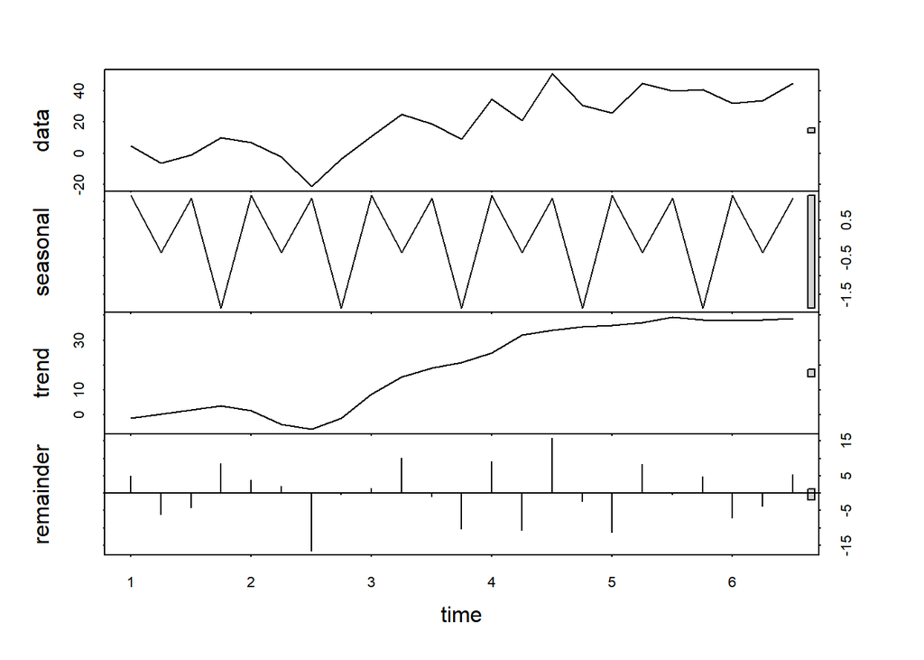

```r
#Baked - in Function
stl(emp_nps$Employer.NPS,s.window = 'periodic')%>%plot
```

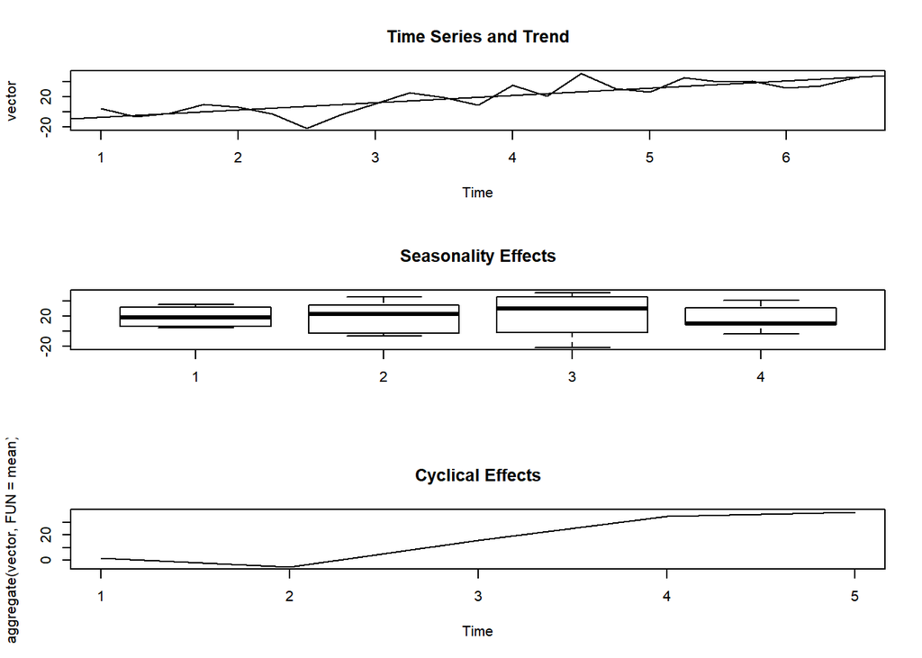

```
##
##  Augmented Dickey-Fuller Test
##
## data:  vector
## Dickey-Fuller = -2.6646, Lag order = 2, p-value = 0.3192
## alternative hypothesis: stationary
```

```r
#Custom function with Dicky-Fuller Test for Stationarity
stationarity_and_cycle_test(emp_nps$Employer.NPS)
```

Both tests show that there is an upward trend, with seasonal effects influencing the outcome. The Dickey-Fuller Test shows a p-value of 0.3192, which indicates this is a non-stationary process needing additional feature transformation and model fitting.

Now, we test Consumer NPS:

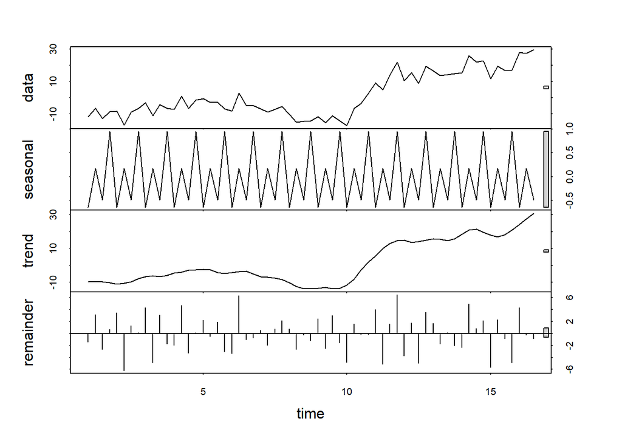

```r
#Baked - in Function
stl(mem_nps$Consumer.NPS,s.window = 'periodic')%>%plot
```

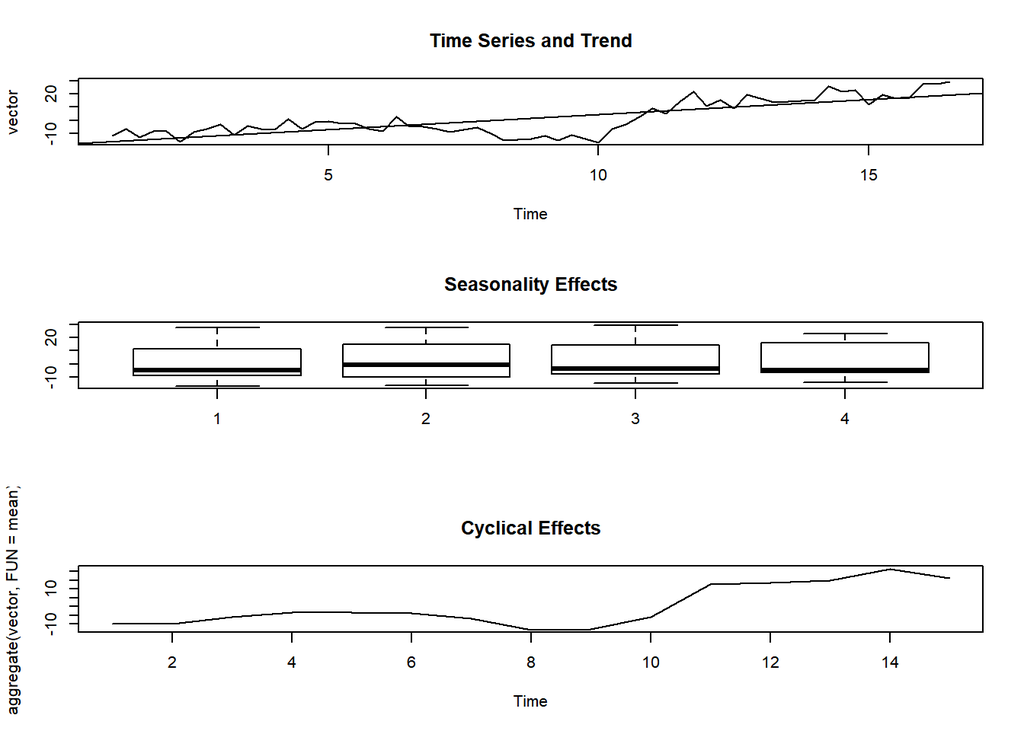

```
##
##  Augmented Dickey-Fuller Test
##
## data:  vector
## Dickey-Fuller = -1.5579, Lag order = 3, p-value = 0.7539
## alternative hypothesis: stationary
```

```r
#Custom function with Dicky-Fuller Test for Stationarity
stationarity_and_cycle_test(mem_nps$Consumer.NPS)
```

Again, both tests show that there is an upward trend, with seasonal effects influencing the outcome. The Dickey-Fuller Test shows a p-value of 0.7539, which indicates this is a non-stationary process needing additional feature transformation and model fitting.

We will now test for Auto-Correlation (ACF) and Partial Auto-Correlation (PACF), which is the data’s relationship with it’s past self.

First we test Employer NPS:

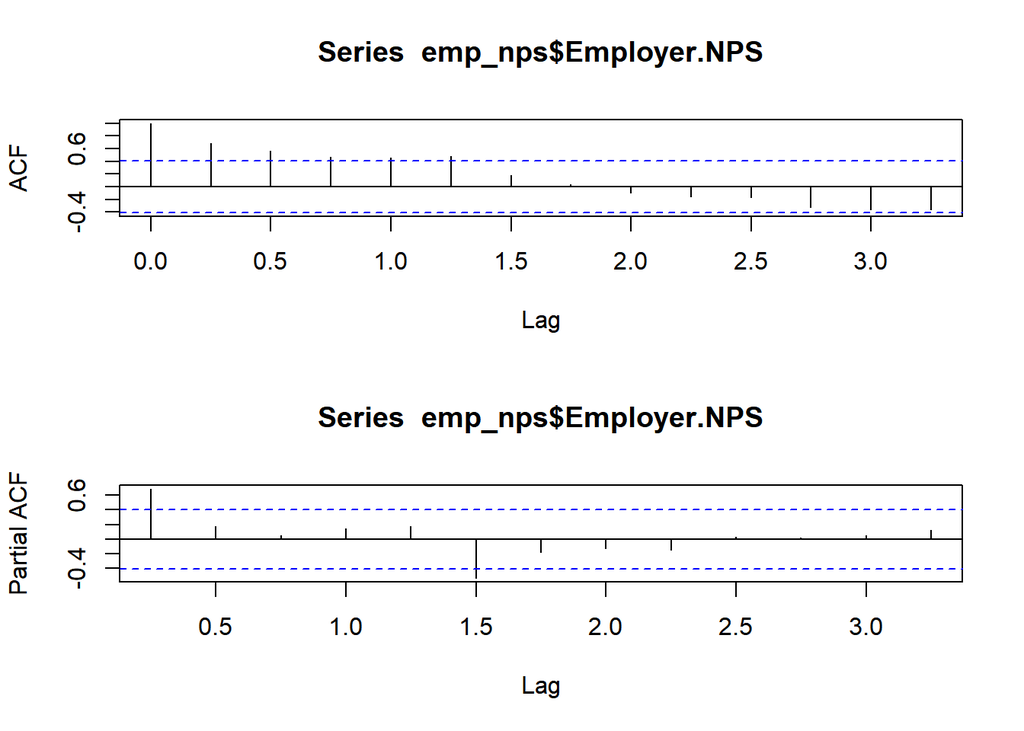

```r
par(mfrow=c(2,1))
acf(emp_nps$Employer.NPS)
pacf(emp_nps$Employer.NPS)
```

For Employer NPS, it takes the ACF 6 periods to decay into the blue bound (which indicates an auto-correlation statistically significant from zero). This indicates that some additional transformation of the data (differencing and a log transform) might be necessary to remove seasonality and variances that do not have an expected value of zero. E(e[t]) != 0 (Equivalent to Heteroskedasticity).

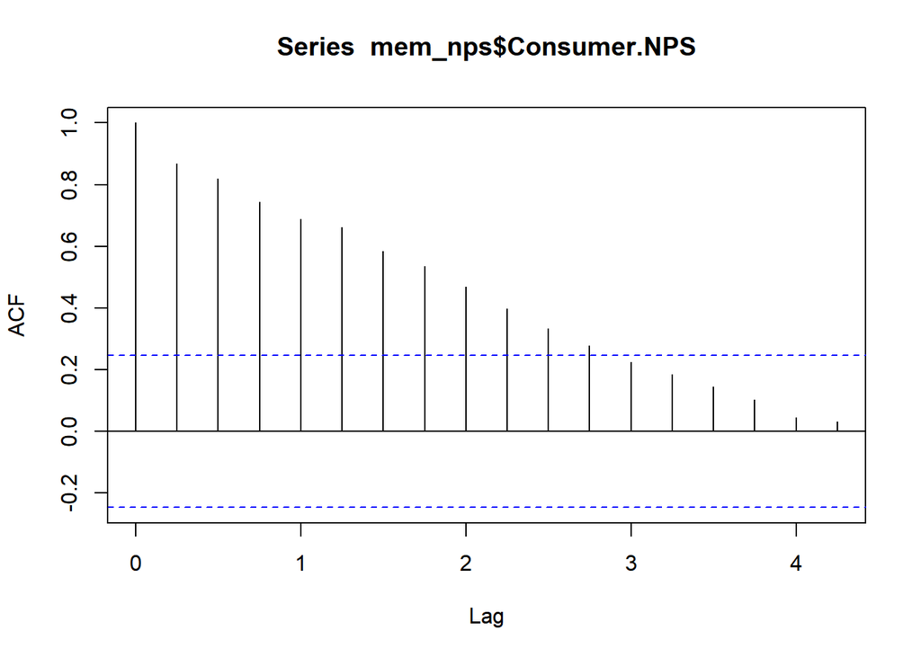

```r
acf(mem_nps$Consumer.NPS)
```

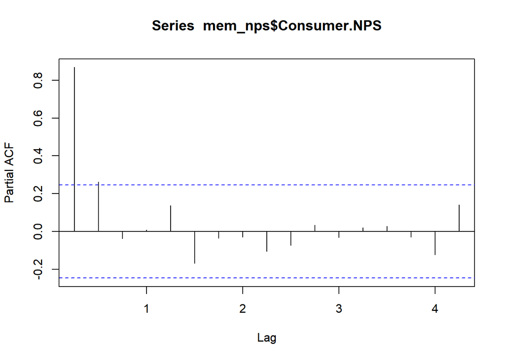

```r
pacf(mem_nps$Consumer.NPS)
```

For Consumer NPS, it takes the ACF 12 periods to decay into the blue bound (which indicates an auto-correlation statistically significant from zero). This indicates that some additional transformation of the data might be needed.

We now modify the data (create new variables) to see how that impacts trend, stationarity, and ACF/PACF tests. We induce a log transform to smooth out the errors and a take a single difference to remove stationarity:

```r
###INDUCING STATIONARITY

#Using a log transform to smooth out unequal variances (akin to inducing Heteroskedastic Robustness)
emp_nps[,log_Employer.NPS:=ts(log(abs(Employer.NPS))*(Employer.NPS/abs(Employer.NPS)),frequency = 4)] #Can't take the log of a negative :)
mem_nps[,log_Consumer.NPS:=ts(log(abs(Consumer.NPS))*(Consumer.NPS/abs(Consumer.NPS)),frequency = 4)]

#Differencing the log_transformed time series by one
emp_nps[,diff_log_Employer.NPS:=ts(diff(log_Employer.NPS),frequency=4)] #Can't take the log of a negative :)
mem_nps[,diff_log_Consumer.NPS:=ts(diff(log_Consumer.NPS),frequency=4)]
```

Now we retest the data to see how it performs.

First we retest Employer NPS:

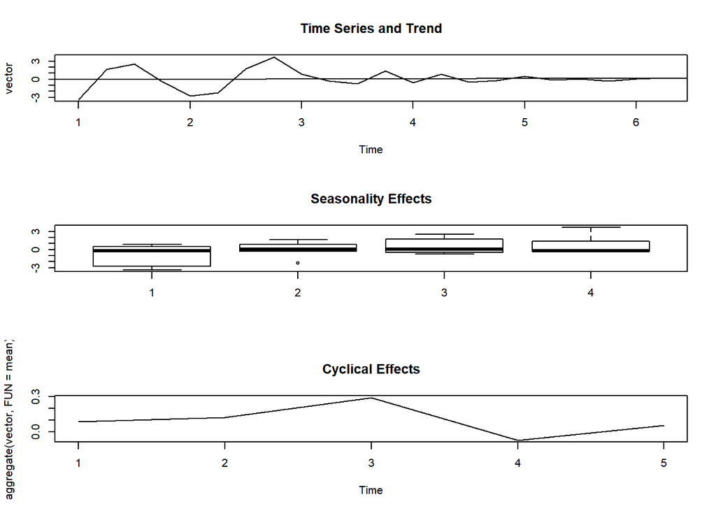

```
##
##  Augmented Dickey-Fuller Test
##
## data:  vector
## Dickey-Fuller = -4.5947, Lag order = 2, p-value = 0.01
## alternative hypothesis: stationary
```

```r
stationarity_and_cycle_test(ts(emp_nps$diff_log_Employer.NPS[1:22],frequency = 4))#Had to strip the last obs due to recycling
```

Employer NPS shows the data transformation smooths out trends, seasonal effects, and cyclical effects. In addition the Dickey-Fuller test p-value is below 0.01, which indicates the process is now stationary and ready for forecasting.

We now retest Consumer NPS:

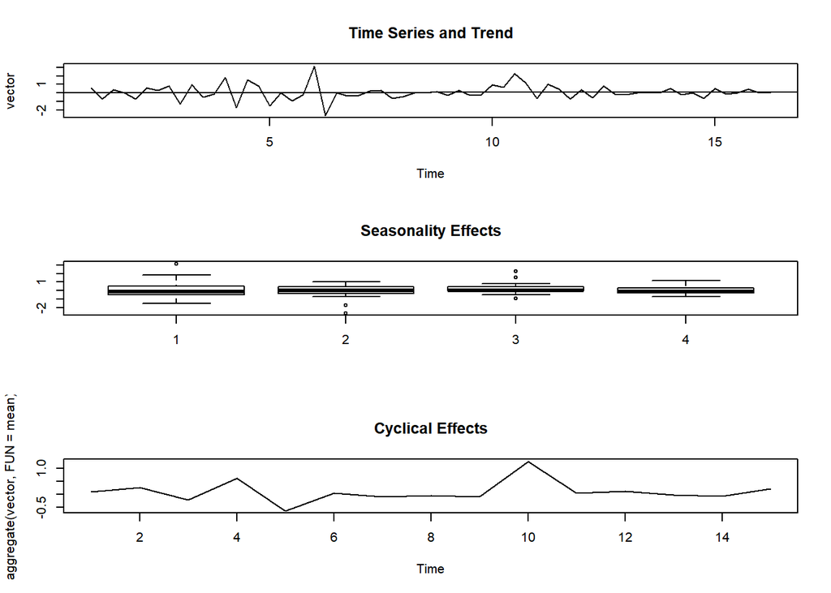

```
##
##  Augmented Dickey-Fuller Test
##
## data:  vector
## Dickey-Fuller = -4.3788, Lag order = 3, p-value = 0.01
## alternative hypothesis: stationary
```

```r
stationarity_and_cycle_test(ts(mem_nps$diff_log_Consumer.NPS[1:62],frequency = 4))
```

Consumer NPS shows the data transformation smooths out trends, seasonal effects, and cyclical effects. In addition the Dickey-Fuller test p-value is below 0.01, which indicates the process is now stationary and ready for forecasting.

We will now double check the ACF/PAC.

First we retest Employer NPS:

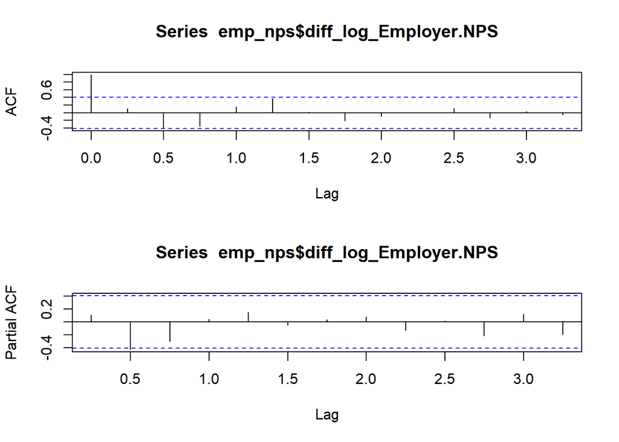

```r
par(mfrow=c(2,1))
acf(emp_nps$diff_log_Employer.NPS)
pacf(emp_nps$diff_log_Employer.NPS)
```

For Employer NPS, the ACF decays after one period, indicating that the additional variance might be explained by a Moving Average or MA(1) model. Adding in the single difference we took, we conclude that we need to use an ARIMA (0,1,1) model for forecasting.

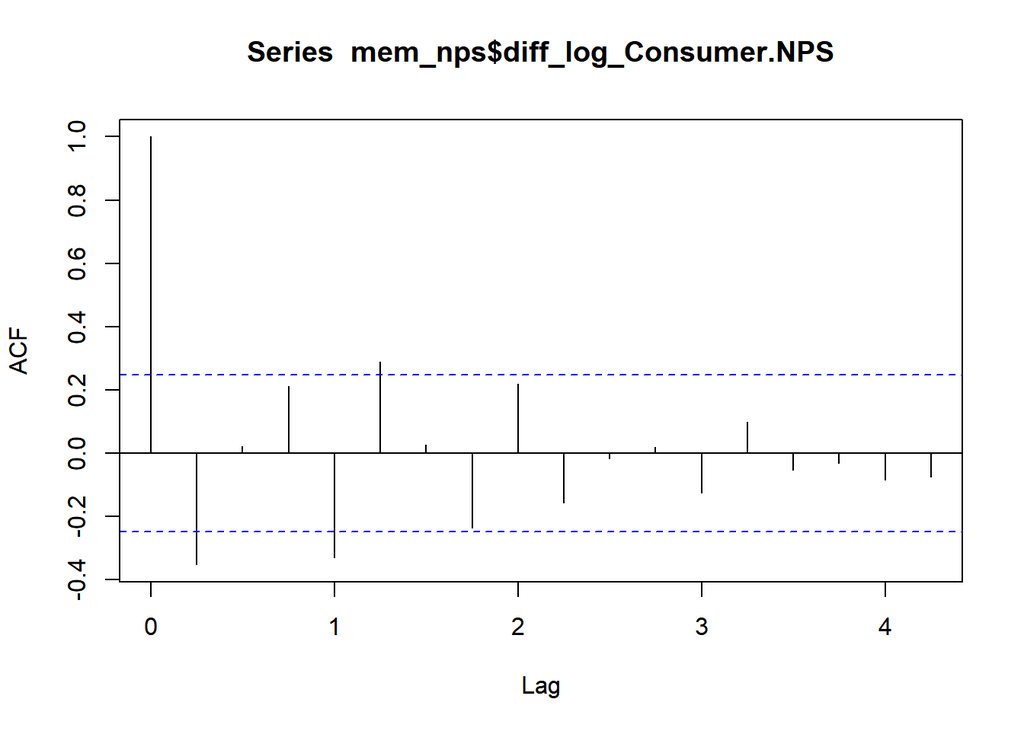

```r
acf(mem_nps$diff_log_Consumer.NPS)
```

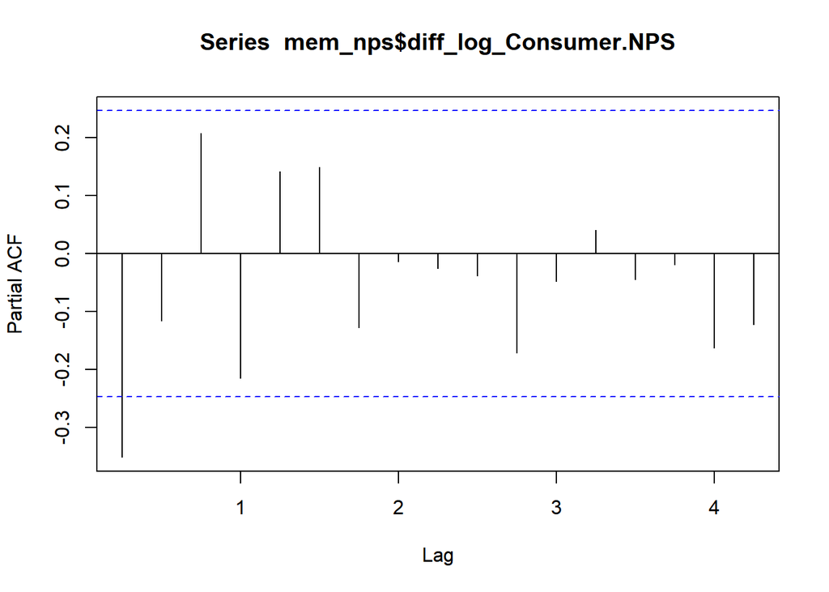

```r
pacf(mem_nps$diff_log_Consumer.NPS)
```

For Consumer NPS, the ACF decays after one period, indicating that the additional variance might be explained by a Moving Average or MA(1) model. The PACF also decays after one period, indicating that variance can also be explained by Auto-Regression or AR(1) model. Adding in the single difference we took, we conclude that we need to use an ARIMA (1,1,1) model for forecasting. But we will also test an ARIMA (0,1,1) and ARIMA (1,1,0) model, since AR and MA effects tend to cancel.

We will now use a concurrent ARIMA(0,1,1) and an automated version of ARIMA to forecast Employer NPS.

```r
#This is the Manual Fitting of the Model
emp_arima=arima(emp_nps$Employer.NPS,order = c(0,1,1),seasonal = list(order = c(0,1,1)))
summary(emp_arima)
```

```
##
## Call:
## arima(x = emp_nps$Employer.NPS, order = c(0, 1, 1), seasonal = list(order = c(0,
##     1, 1)))
##
## Coefficients:
##           ma1     sma1
##       -0.6689  -0.8115
## s.e.   0.2752   0.6070
##
## sigma^2 estimated as 201.9:  log likelihood = -75.7,  aic = 157.4
##
## Training set error measures:
##                     ME     RMSE      MAE      MPE     MAPE      MASE
## Training set 0.9968927 12.57044 8.870226 12.98231 44.74514 0.7415009
##                    ACF1
## Training set 0.04919503
```

```r
BIC(emp_arima)
```

```
## [1] 160.0683
```

```r
#This is the automated fit
au_emp_arima=auto.arima(emp_nps$Employer.NPS,stationary = F,seasonal = T)
summary(au_emp_arima)
```

```
## Series: emp_nps$Employer.NPS
## ARIMA(0,1,0)
##
## sigma^2 estimated as 199.2:  log likelihood=-89.45
## AIC=180.91   AICc=181.11   BIC=182
##
## Training set error measures:
##                   ME     RMSE      MAE       MPE     MAPE      MASE
## Training set 1.75176 13.80374 11.44262 -4.901825 105.5465 0.7688491
##                    ACF1
## Training set -0.3543596
```

The manually selected ARIMA(0,1,1) model demonstrates more favorable criterion over the ARIMA (0,1,0) (Essentially a single differenced equation) that the forecast::auto.arima function chose. It has a lower Aikake and Bayes information criterion (AIC/BIC) as well as a lower Residual Mean Sum of Errors (RMSE).

We will now visualize the forecasts and perform validation:

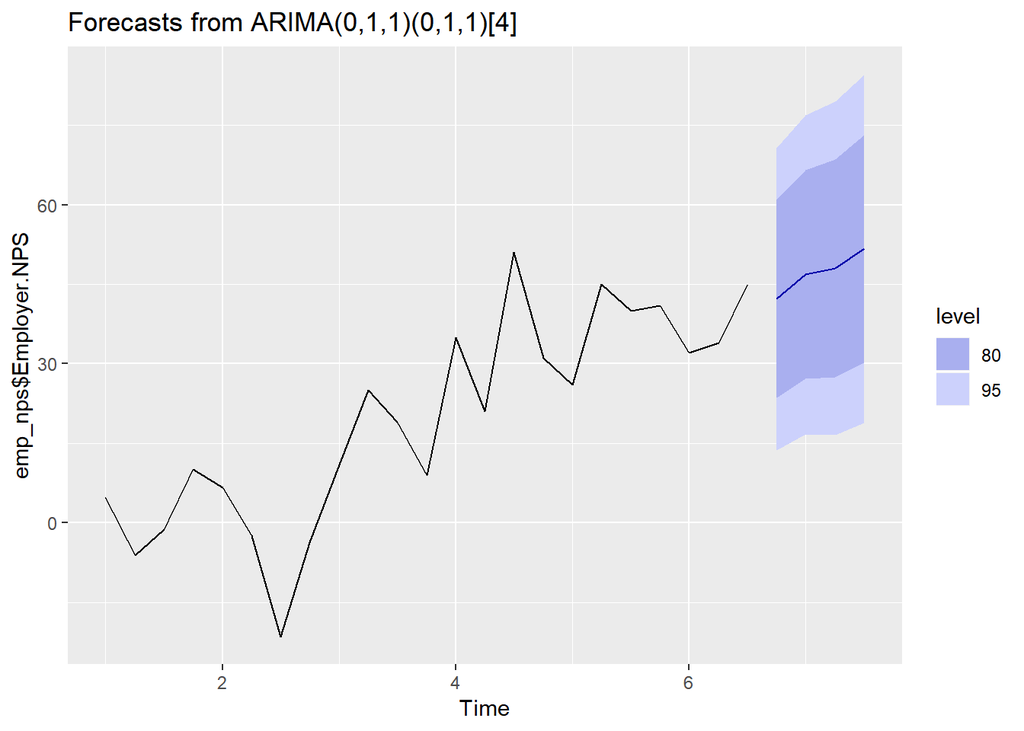

```r
fit_emp_arima=forecast(emp_arima,h=4)
fit_au_emp_arima=forecast(au_emp_arima,h=4)
autoplot(fit_emp_arima)
```

The ARIMA(0,1,1) model shows a moderately increasing future trend, with both 80and 95 % confidence intervals indicating a possibility of the trend plateauing.

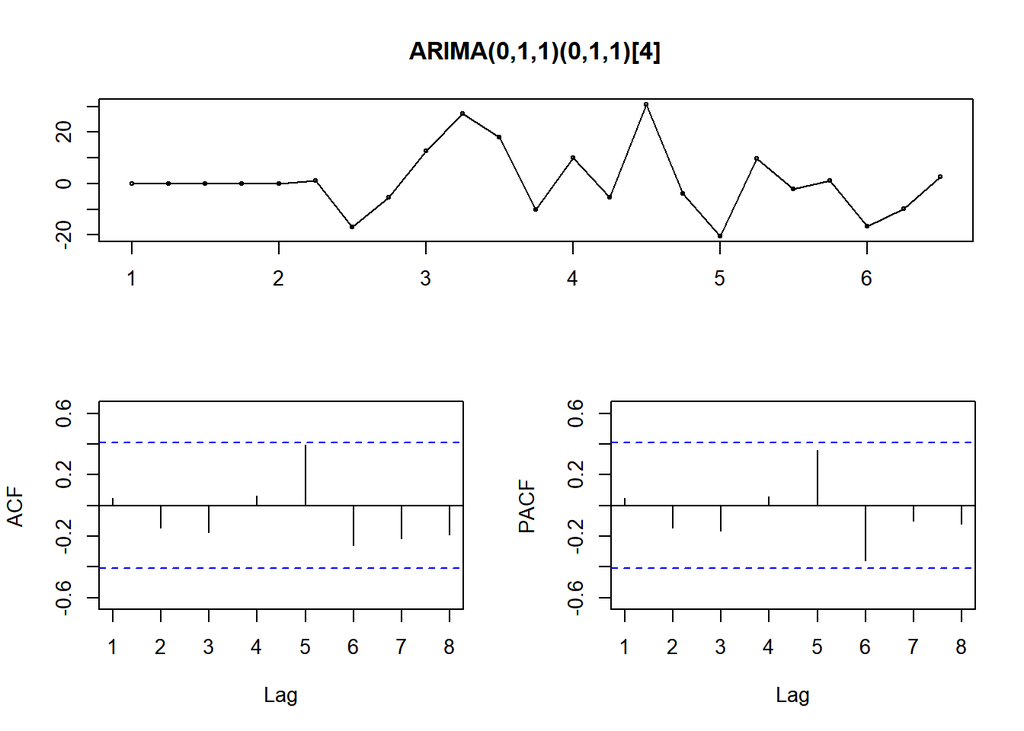

```r
fit_emp_arima$residuals%>%tsdisplay(main=fit_emp_arima$method)
```

The above manual fit shows a mean-reverting trend (Homoskedastic) amongst the errors and no Auto correlation or Moving Average indicators visible among the ACF and PACF. This model is satisfactory.

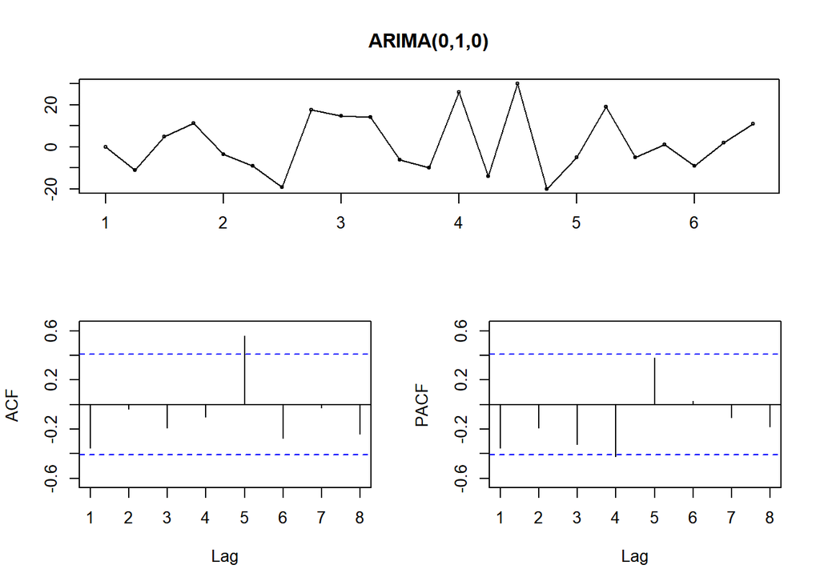

```r
fit_au_emp_arima$residuals%>%tsdisplay(main=fit_au_emp_arima$method)
```

Compare this to the above automated fit. While the trend seems to be mean-reverting, the ACF seams to indicate that we missed a relationship between errors. The ACF seems to indicate this occurs in Lag 5, but its possible it could have occurred earlier.

We will now forecast and validate Consumer NPS:

```r
mem_arima_011=arima(mem_nps$Consumer.NPS,order = c(0,1,1),seasonal = list(order = c(0,1,1)))
summary(mem_arima_011)
```

```
##
## Call:
## arima(x = mem_nps$Consumer.NPS, order = c(0, 1, 1), seasonal = list(order = c(0,
##     1, 1)))
##
## Coefficients:
##           ma1     sma1
##       -0.3894  -1.0000
## s.e.   0.1092   0.1364
##
## sigma^2 estimated as 26.85:  log likelihood = -183.3,  aic = 372.6
##
## Training set error measures:
##                     ME     RMSE      MAE      MPE     MAPE     MASE
## Training set 0.4398726 4.971832 3.826263 25.22593 65.37354 0.853843
##                     ACF1
## Training set -0.05103929
```

```r
BIC(mem_arima_011)
```

```
## [1] 378.7827
```

```r
mem_arima_111=arima(mem_nps$Consumer.NPS,order = c(1,1,1),seasonal = list(order = c(0,1,1)))
summary(mem_arima_111)
```

```
##
## Call:
## arima(x = mem_nps$Consumer.NPS, order = c(1, 1, 1), seasonal = list(order = c(0,
##     1, 1)))
##
## Coefficients:
##           ar1      ma1     sma1
##       -0.2325  -0.1984  -1.0000
## s.e.   0.2875   0.2836   0.1316
##
## sigma^2 estimated as 26.58:  log likelihood = -183,  aic = 374
##
## Training set error measures:
##                    ME     RMSE      MAE      MPE     MAPE      MASE
## Training set 0.439536 4.947184 3.785938 24.55154 65.75591 0.8448443
##                      ACF1
## Training set -0.009327906
```

```r
BIC(mem_arima_111)
```

```
## [1] 382.2422
```

```r
au_mem_arima=auto.arima(mem_nps$Consumer.NPS,stationary = F,seasonal = T)
summary(au_mem_arima)
```

```
## Series: mem_nps$Consumer.NPS
## ARIMA(1,1,0)
##
## Coefficients:
##           ar1
##       -0.3976
## s.e.   0.1161
##
## sigma^2 estimated as 26.93:  log likelihood=-189.65
## AIC=383.3   AICc=383.51   BIC=387.56
##
## Training set error measures:
##                     ME     RMSE      MAE     MPE     MAPE      MASE
## Training set 0.8959605 5.106746 4.000203 12.7631 72.36213 0.6203174
##                    ACF1
## Training set -0.0616199
```

We will now visually inspect both ARIMA(0,1,1) and ARIMA(1,1,1):

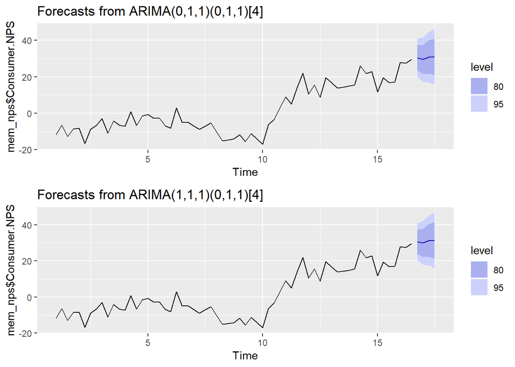

```r
fit_mem_arima_011=forecast(mem_arima_011,h=4)
fit_mem_arima_111=forecast(mem_arima_111,h=4)

x=autoplot(fit_mem_arima_011)
y=autoplot(fit_mem_arima_111)
gridExtra::grid.arrange(x,y)
```

Both models indicate an upward trend, with little overall difference in confidence intervals on the upper bounds. However, the favored model, ARIMA(0,1,1) indicates a stronger possibility of plateauing in the next several quarters.

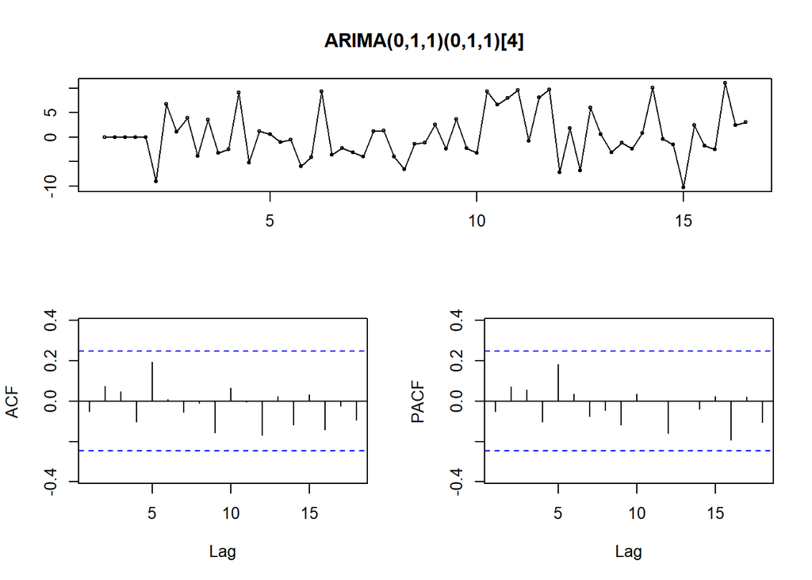

```r
fit_mem_arima_011$residuals%>%tsdisplay(main=fit_mem_arima_011$method)
```

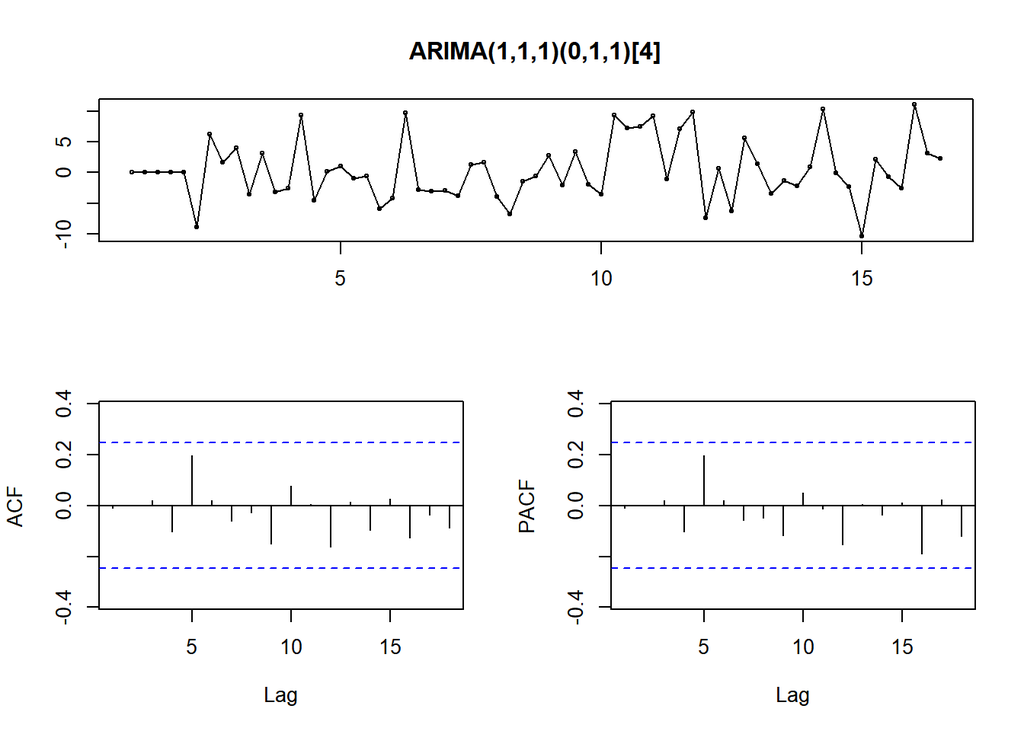

```r
fit_mem_arima_111$residuals%>%tsdisplay(main=fit_mem_arima_111$method)
```

We will now construct the data set for the Employer Data set and display the forecast for 4 additional quarters past Q3 2018.

```r
fitted_emp=data.table(quarter=as.character(emp_nps$Quarter),data=as.numeric(emp_nps$Employer.NPS))

fitted_emp=rbind(fitted_emp
                 ,data.table(quarter="Q4 '18", data.table(data=fit_emp_arima$mean[1]))
                 ,data.table(quarter=paste0('Q',rep(1:3)," '19"),data.table(data=fit_emp_arima$mean[2:4])))
```

Below are the estimates for Employer NPS using an ARIMA(0,1,1) Model:

```r
fitted_emp
```

```
##     quarter       data
##  1:  Q1 '13   4.714242
##  2:  Q2 '13  -6.210115
##  3:  Q3 '13  -1.209852
##  4:  Q4 '13  10.053100
##  5:  Q1 '14   6.675701
##  6:  Q2 '14  -2.370503
##  7:  Q3 '14 -21.467481
##  8:  Q4 '14  -3.749522
##  9:  Q1 '15  10.914412
## 10:  Q2 '15  25.000000
## 11:  Q3 '15  19.000000
## 12:  Q4 '15   9.000000
## 13:  Q1 '16  35.000000
## 14:  Q2 '16  21.000000
## 15:  Q3 '16  51.000000
## 16:  Q4 '16  31.000000
## 17:  Q1 '17  26.000000
## 18:  Q2 '17  45.000000
## 19:  Q3 '17  40.000000
## 20:  Q4 '17  41.000000
## 21:  Q1 '18  32.000000
## 22:  Q2 '18  34.000000
## 23:  Q3 '18  45.000000
## 24:  Q4 '18  42.237675
## 25:  Q1 '19  46.831092
## 26:  Q2 '19  48.023469
## 27:  Q3 '19  51.699149
##     quarter       data
```

We will now construct the data set for the Consumer Data set and display the forecast for 4 additional quarters past Q3 2018.

```r
fitted_mem=data.table(quarter=as.character(mem_nps$Quarter),data=as.numeric(mem_nps$Consumer.NPS))

fitted_mem=rbind(fitted_mem
                 ,data.table(quarter="Q4 2018", data.table(data=fit_mem_arima_011$mean[1]))
                 ,data.table(quarter=paste0('Q',rep(1:3)," 2019"),data.table(data=fit_mem_arima_011$mean[2:4])))
```

Below are the estimates for Consumer NPS using an ARIMA(0,1,1) Model:

```r
fitted_mem
```

```
##     quarter        data
##  1: Q1 2003 -11.7166213
##  2: Q2 2003  -6.3829787
##  3: Q3 2003 -12.8517824
##  4: Q4 2003  -8.5397096
##  5: Q1 2004  -8.2130966
##  6: Q2 2004 -16.6481687
##  7: Q3 2004  -8.8636364
##  8: Q4 2004  -6.6344994
##  9: Q1 2005  -2.9972752
## 10: Q2 2005 -10.9395109
## 11: Q3 2005  -4.1443850
## 12: Q4 2005  -6.5508021
## 13: Q1 2006  -7.1590909
## 14: Q2 2006   0.8464329
```

[output cut: 54 more lines]

Finally, we save both data sets for future analysis:

```r
fwrite(fitted_emp,'c:/Users/r633157/Documents/employer_nps_forecast_q42018.csv')
fwrite(fitted_mem,'c:/Users/r633157/Documents/consumer_nps_forecast_q42018.csv')
```

Conclusion:

With little data, and holding all potential variables and shocks constant, we see a forecasted increase in NPS for both consumer and employers.